# Human Activity Recognition - Weight Lifting Classification

Antonio camacho

July 24, 2016

## Background

Using devices such as Jawbone Up, Nike FuelBand, and Fitbit it is now possible to collect a large amount of data about personal activity relatively inexpensively. These type of devices are part of the quantified self movement - a group of enthusiasts who take measurements about themselves regularly to improve their health, to find patterns in their behavior, or because they are tech geeks. One thing that people regularly do is quantify how much of a particular activity they do, but they rarely quantify how well they do it. In this project, your goal will be to use data from accelerometers on the belt, forearm, arm, and dumbell of 6 participants. They were asked to perform barbell lifts correctly and incorrectly in 5 different ways. More information is available from the website here: [dataset website](http://groupware.les.inf.puc-rio.br/har) (see the section on the Weight Lifting Exercise Dataset).

Participants were asked to perform one set of 10 repetitions of the Unilateral Dumbbell Biceps Curl in five different fashions: exactly according to the specification (Class A), throwing the elbows to the front (Class B), lifting the dumbbell only halfway (Class C), lowering the dumbbell only halfway (Class D) and throwing the hips to the front (Class E).

## Executive Summary

After exploring data and looking for NAs, near zero variance predictors, and highly correlated predictors, 114 of this predictors where removed from model building. Random forest has been used as a high accuracy classifier in order to calculate out of sample accuracy and classify barbell lifts on the test / validation data set. The final model has an accuracy of 99.25% in the test data set.

## Analysis

```r
library(dplyr)
library(ggplot2)
library(caret)
library(parallel)
library(doParallel)
```

### Downloading and loading the data

```r
if(!file.exists("~/rdir/data/pml-training.csv")){
    url1<-"https://d396qusza40orc.cloudfront.net/predmachlearn/pml-training.csv"
    download.file(url=url1,destfile="~/rdir/data/pml-training.csv",extra = c("curl"))
}
if(!file.exists("~/rdir/data/pml-testing.csv")){
    url2<-"https://d396qusza40orc.cloudfront.net/predmachlearn/pml-testing.csv"
    download.file(url=url2,destfile="~/rdir/data/pml-testing.csv",extra = c("curl"))
}
training<-read.csv(file ="~/rdir/data/pml-training.csv",na.strings = c("NA","#DIV/0!"))
validation<-read.csv(file="~/rdir/data/pml-testing.csv",na.strings = c("NA","#DIV/0!"))
```

### Exploratory Data Analysis

We will proceed to do some exploratory data analysis in order to obtain some intuition about the the data. We will look for NAs, predictors with near zero variance and highly correlated predictors. We will also take a look at the counts of classes in the training data set.

```r
# How big is the data?
dim(training);
```

```
## [1] 19622   160
```

```r
dim(validation)
```

```
## [1]  20 160
```

```r
# Histogram of classes
table(training$classe)
```

```
##
##    A    B    C    D    E
## 5580 3797 3422 3216 3607
```

```r
# Inspect for NA values and count how many there are in
# each column
na <- apply(training,2, function(x) sum(is.na(x)) )

# columns counts of NA values
na[na > 0]
```

```
##       kurtosis_roll_belt      kurtosis_picth_belt        kurtosis_yaw_belt
##                    19226                    19248                    19622
##       skewness_roll_belt     skewness_roll_belt.1        skewness_yaw_belt
##                    19225                    19248                    19622
##            max_roll_belt           max_picth_belt             max_yaw_belt
##                    19216                    19216                    19226
##            min_roll_belt           min_pitch_belt             min_yaw_belt
##                    19216                    19216                    19226
##      amplitude_roll_belt     amplitude_pitch_belt       amplitude_yaw_belt
##                    19216                    19216                    19226
##     var_total_accel_belt            avg_roll_belt         stddev_roll_belt
##                    19216                    19216                    19216
##            var_roll_belt           avg_pitch_belt        stddev_pitch_belt
##                    19216                    19216                    19216
##           var_pitch_belt             avg_yaw_belt          stddev_yaw_belt
##                    19216                    19216                    19216
##             var_yaw_belt            var_accel_arm             avg_roll_arm
##                    19216                    19216                    19216
##          stddev_roll_arm             var_roll_arm            avg_pitch_arm
##                    19216                    19216                    19216
##         stddev_pitch_arm            var_pitch_arm              avg_yaw_arm
##                    19216                    19216                    19216
##           stddev_yaw_arm              var_yaw_arm        kurtosis_roll_arm
##                    19216                    19216                    19294
##       kurtosis_picth_arm         kurtosis_yaw_arm        skewness_roll_arm
##                    19296                    19227                    19293
##       skewness_pitch_arm         skewness_yaw_arm             max_roll_arm
##                    19296                    19227                    19216
##            max_picth_arm              max_yaw_arm             min_roll_arm
##                    19216                    19216                    19216
##            min_pitch_arm              min_yaw_arm       amplitude_roll_arm
##                    19216                    19216                    19216
##      amplitude_pitch_arm        amplitude_yaw_arm   kurtosis_roll_dumbbell
##                    19216                    19216                    19221
##  kurtosis_picth_dumbbell    kurtosis_yaw_dumbbell   skewness_roll_dumbbell
##                    19218                    19622                    19220
##  skewness_pitch_dumbbell    skewness_yaw_dumbbell        max_roll_dumbbell
##                    19217                    19622                    19216
##       max_picth_dumbbell         max_yaw_dumbbell        min_roll_dumbbell
##                    19216                    19221                    19216
```

[output cut: 13 more lines]

```
##                    19299                    19301                    19622
##         max_roll_forearm        max_picth_forearm          max_yaw_forearm
##                    19216                    19216                    19300
##         min_roll_forearm        min_pitch_forearm          min_yaw_forearm
##                    19216                    19216                    19300
##   amplitude_roll_forearm  amplitude_pitch_forearm    amplitude_yaw_forearm
##                    19216                    19216                    19300
##        var_accel_forearm         avg_roll_forearm      stddev_roll_forearm
##                    19216                    19216                    19216
##         var_roll_forearm        avg_pitch_forearm     stddev_pitch_forearm
##                    19216                    19216                    19216
##        var_pitch_forearm          avg_yaw_forearm       stddev_yaw_forearm
##                    19216                    19216                    19216
##          var_yaw_forearm
##                    19216
```

```r
# Near Zero Variance Predictors
nzv <- nearZeroVar(training, saveMetrics= TRUE)
# number of predictors with near zero variance
nzv %>% filter(nzv == TRUE) %>% nrow()
```

```
## [1] 36
```

```r
# Find out about highly correlated (numeric) predictors
# of columns without NA values

training.complete <-
    training %>%
    select(which(colSums(is.na(.))==0)) # remove cols with NAs

# correlation matrix of numeric predictors
numericColumns <- sapply(training.complete, is.numeric)
corMatrix<-cor(training.complete[,numericColumns])
# find highly correlated columns to later remove
highCor <- findCorrelation(corMatrix,cutoff = .90)
highCorColumns <- dimnames(corMatrix)[[1]][highCor]

unlink(training.complete) # no more need of this variable
```

### Data pre-processing

In this section we will proceed to remove:

- columns filled with NA values (as we saw most of the values are missing for these predictors)
- predictors with near zero variance
- high correlated predictors
- predictors with low predictive value (column ids and time stamps)

```r
# remove near zero variance predictors
training <- training[,nzv$nzv == FALSE]
# remove columns filled with NAs
training <- training %>% select(which(colSums(is.na(.))==0))
# romove highly correlated predictors
training <- training %>% select(-which(names(.) %in% highCorColumns))

#remove unecesary predictors unrelated to sensor data
training$X <- NULL
training$user_name <- NULL
training$raw_timestamp_part_1 <- NULL
training$raw_timestamp_part_2 <- NULL
training$cvtd_timestamp <- NULL
training$num_window <- NULL

dim(training)
```

```
## [1] 19622    46
```

After removing all these predictors the number of dimensions have been reduced to 46 from an initial value of 160.

### Model Building

We are going to build a classifier using [random forest](https://en.wikipedia.org/wiki/Random_forest) which is one of the high performance algorithms used in classification problems and can be used to rank the importance of variables. Random forest have high accuracy but it is computationally intensive.

```r
set.seed(12345)
inTrain <- createDataPartition(y=training$classe,p=0.6,list=FALSE)
training.sub <- training[inTrain,] # model building training set
testing.sub <- training[-inTrain,] # model building test set

# check if model has already been created (this will only run once!)
if(!file.exists("~/rdir/data/har_model_rf_fit.rda") ){
    # Allow for parallel computing
    cluster <- makeCluster(detectCores() - 1) # convention to leave 1 core for OS
    registerDoParallel(cluster)

    # set seed to generate reproducible results
    set.seed(12345)
    trainCtrl <- trainControl(method = "cv", number = 10, allowParallel = TRUE)
    fit <- train(classe~.,
                 data = training.sub,
                 method = "rf",
                 prox = TRUE,
                 trControl =trainCtrl,
                 ntree=1000)
    stopCluster(cluster)

    # save for later use
    save(fit,file ="~/rdir/data/har_model_rf_fit.rda")
}else{
    # load model from hard drive
    load("~/rdir/data/har_model_rf_fit.rda")
}

# Model Summary
print(fit)
```

```
## Random Forest
##
## 11776 samples
##    45 predictor
##     5 classes: 'A', 'B', 'C', 'D', 'E'
##
## No pre-processing
## Resampling: Cross-Validated (10 fold)
## Summary of sample sizes: 10598, 10599, 10600, 10599, 10598, 10599, ...
## Resampling results across tuning parameters:
##
##   mtry  Accuracy   Kappa
##    2    0.9887079  0.9857143
##   23    0.9893017  0.9864661
##   45    0.9862446  0.9825972
##
## Accuracy was used to select the optimal model using  the largest value.
## The final value used for the model was mtry = 23.
```

### Cross validation Accuracy and out of sample error

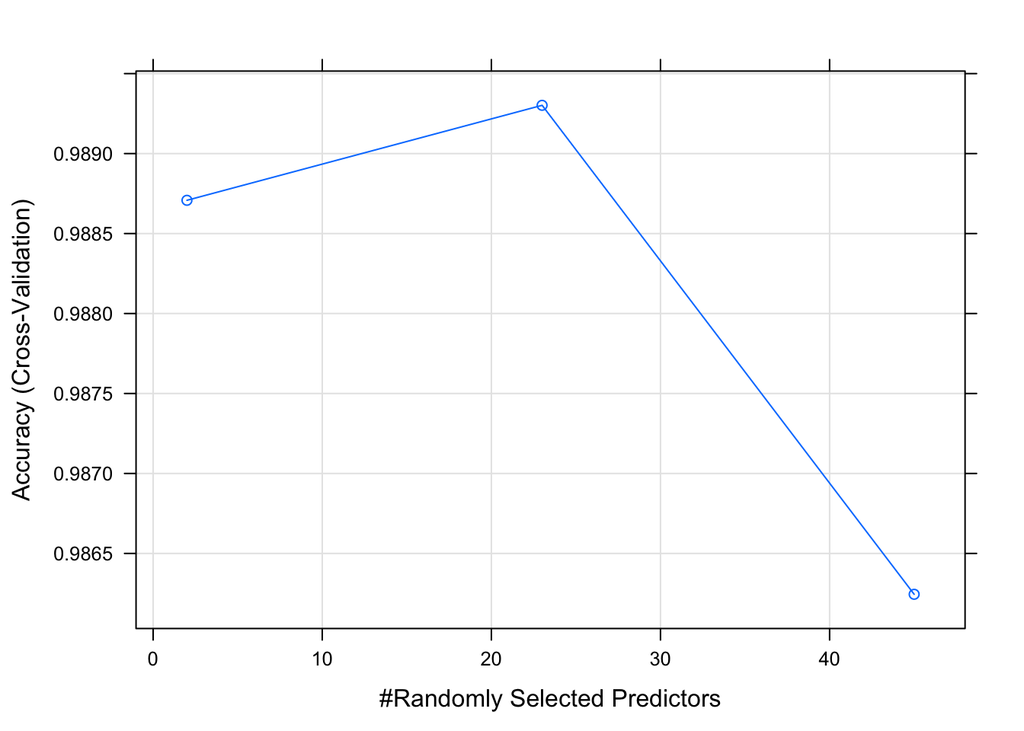

```r
plot(fit)
```

### Out of sample error on test dataset

```r
# prediction
yhat <- predict(fit,testing.sub)
# confussion matrix
confusionMatrix(yhat,testing.sub$classe)
```

```
## Confusion Matrix and Statistics
##
##           Reference
## Prediction    A    B    C    D    E
##          A 2228   10    0    0    0
##          B    4 1501    8    0    0
##          C    0    7 1357   17    2
##          D    0    0    3 1267    6
##          E    0    0    0    2 1434
##
## Overall Statistics
##
##                Accuracy : 0.9925
##                  95% CI : (0.9903, 0.9943)
##     No Information Rate : 0.2845
##     P-Value [Acc > NIR] : < 2.2e-16
##
##                   Kappa : 0.9905
##  Mcnemar's Test P-Value : NA
##
## Statistics by Class:
##
##                      Class: A Class: B Class: C Class: D Class: E
## Sensitivity            0.9982   0.9888   0.9920   0.9852   0.9945
## Specificity            0.9982   0.9981   0.9960   0.9986   0.9997
## Pos Pred Value         0.9955   0.9921   0.9812   0.9929   0.9986
## Neg Pred Value         0.9993   0.9973   0.9983   0.9971   0.9988
## Prevalence             0.2845   0.1935   0.1744   0.1639   0.1838
## Detection Rate         0.2840   0.1913   0.1730   0.1615   0.1828
## Detection Prevalence   0.2852   0.1928   0.1763   0.1626   0.1830
## Balanced Accuracy      0.9982   0.9935   0.9940   0.9919   0.9971
```

### Predictions on validation set

```r
# predictions on validation set
yhatValidation <- predict(fit,validation)
# display answers
as.character(yhatValidation)
```

```
##  [1] "B" "A" "B" "A" "A" "E" "D" "B" "A" "A" "B" "C" "B" "A" "E" "E" "A"
## [18] "B" "B" "B"
```

### Conclussion

Random forest produces a high accuracy classifier (99.25%) on the test data of the weight lifting data set after removing 114 unnecessary predictors. There is a big computational cost on building the model. Parallel computing was used to reduce the time needed to produce the classifier.

## Appendix

### Predictors importance

```r
varImp(fit)
```

```
## rf variable importance
##
##   only 20 most important variables shown (out of 45)
##
##                      Overall
## yaw_belt              100.00
## pitch_forearm          82.77
## pitch_belt             68.73
## magnet_dumbbell_z      63.76
## magnet_dumbbell_y      49.88
## roll_forearm           43.98
## magnet_belt_y          42.45
## gyros_belt_z           29.59
## magnet_belt_z          27.43
## magnet_dumbbell_x      26.92
## accel_dumbbell_y       25.69
## roll_dumbbell          24.35
## accel_forearm_x        22.67
## accel_forearm_z        18.89
## magnet_belt_x          18.84
## accel_dumbbell_z       18.11
## total_accel_belt       16.79
## total_accel_dumbbell   16.51
## magnet_forearm_z       16.17
## yaw_arm                13.62
```

### Classe distribution in training set

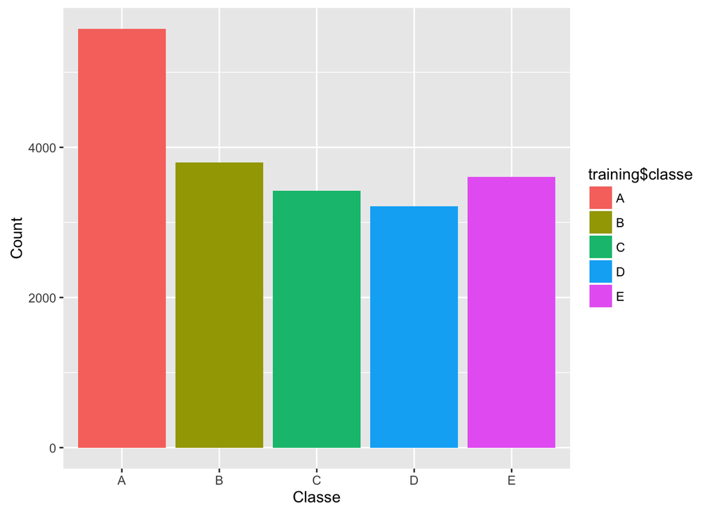

```r
qplot(training$classe,xlab="Classe",ylab="Count",fill=training$classe)
```

**Figure 2** *Classe* counts in training data set

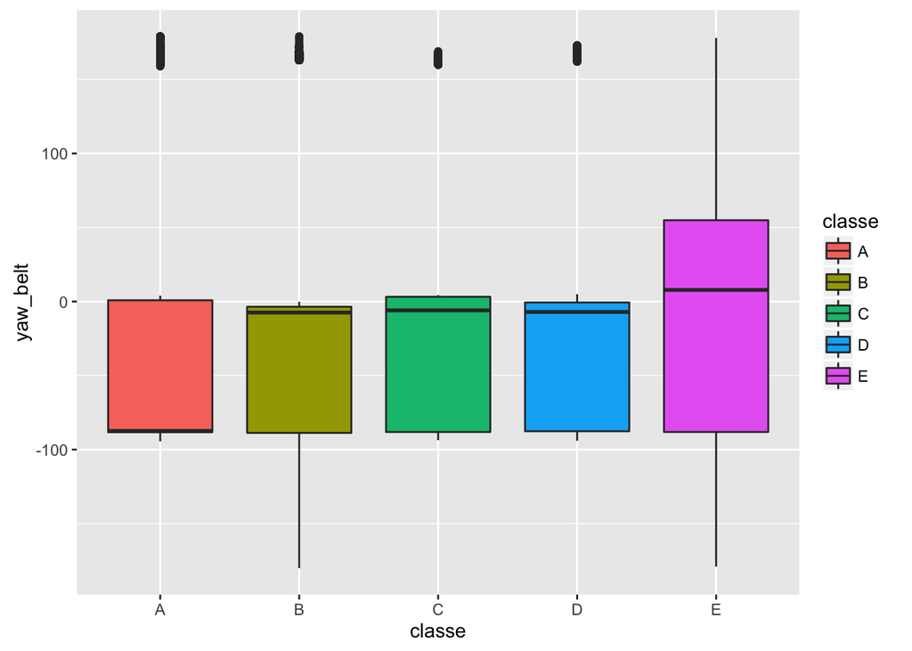

```r
# most important variable
g <- ggplot(training,aes(classe,yaw_belt))
g <- g + geom_boxplot(aes(fill = classe))
g
```

**Figure 3** *Classe* versus *yaw_belt* (most important variable)

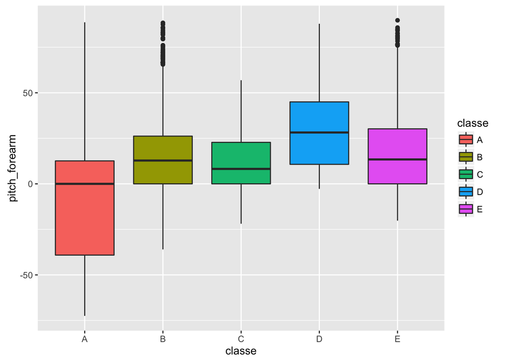

```r
# second most important variable
g <- ggplot(training,aes(classe,pitch_forearm))
g <- g + geom_boxplot(aes(fill = classe))
g
```

**Figure 4** *Classe* versus *pitch_forearm* (second most important variable)